# 401-2_Homework1

Author

Cat Dang Ton

Published

April 4, 2024

```r
library(pacman)
p_load (tidyverse, haven, modelsummary, marginaleffects, estimatr, psych, MASS)
rm(list = ls()) # refresh environment
df_raw <- read.csv("../02_Merge/Output/widows_with_demog_and_tracker.csv")
```

## 1.

I am using data from the 2022 Health and Retirement Survey. The sample consists of respondents to the survey’s subsection on Widowhood and Divorce, who experienced the death of a spouse between 2020 and 2022.

Dependent variable: whether or not the widowed spouse had to sell assets, withdraw money that normally would not be touched, get help from a relative, or from a church or other institution, or do anything else special to find the money to cover the deceased spouse’s death expenses (funeral expenses, legal fees, expenses for any illness that led to death). (Yes = 1, No = 0). Let’s say that this means the widow had difficulty covering such final expenses.

Independent variables:

1. Whether the living spouse is US-born or foreign born (US-born = 1, foreign-born = 0)
2. Total death expenses that are NOT covered by insurance or the deceased spouse’s estate (Exact dollar amounts, or if not available, the midpoint of approximated estimates)

```r
# Select relevant variables; recode categorical variables
df <- df_raw %>%
    filter(USBORN %in% c(1,5), !is.na(SS048M1)) %>%
    dplyr::select(respondent_id, USBORN, DEGREE, SS048M1, SS044, SS045, SS046, SS047) %>%
    mutate(deathexpense_special = case_when(SS048M1 %in% c(1,2,3,4,7) ~ 1, SS048M1 == 5 ~ 0, TRUE ~ NA)) %>%
    mutate(usborn = case_when(USBORN == 1 ~ 1, USBORN == 5 ~ 0, TRUE ~ NA))

# convert variables to factor format to present descriptive matrix
# should not factor the dependent variable
# df$deathexpense_special <- factor(df$deathexpense_special, levels = c(0, 1), labels = c("no", "yes"))
df$usborn <- factor(df$usborn, levels = c(0, 1), labels = c("foreign", "us-born"))

# Recode Degree into a factor variable

df$degree <- factor(df$DEGREE,
                    levels = c(0, 1, 2, 3, 4, 5, 6, 9),
                    labels = c("No degree",
                               "GED",
                               "High school diploma",
                               "Two year college degree",
                               "Four year college degree",
                               "Master degree",
                               "Professional degree (Ph.D., M.D., J.D.)",
                               "Degree unknown/Some College"))

# make descriptive crosstabs
table1 <- table(df$deathexpense_special, df$usborn)
table2 <- table(df$deathexpense_special, df$degree)
print(table1)
```

```
    foreign us-born
  0      39     290
  1      30      73
```

```r
print(table2)
```

```
    No degree GED High school diploma Two year college degree
  0        57  22                 162                      27
  1        25   8                  39                      10

    Four year college degree Master degree
  0                       32            12
  1                        8             6

    Professional degree (Ph.D., M.D., J.D.) Degree unknown/Some College
  0                                       2                          15
  1                                       2                           5
```

```r
# Ignore the Degree variable for now, not sure what is going on
```

```r
library(purrr)

# Recode SS044 (death expenses reported in exact dollar amounts) into 'deathexpense_usd'
# 9999999: Refused
# -8: web non-answer
# HOWEVER some -8 answers did subsequently give range estimates.
# It's confusing; I'm still trying to figure it out.
df <- df %>%
  mutate(deathexpense_usd = SS044)

# Cases coded as 9999998 in SS044 included both "dont know" and "not ascertained",
# and so the surveyor moves onto questions SS045-046 to obtain an approximate range (less than 2000, 2000-10000, more then 10000).
#
# Recode SS045 (expense estimates, min) and SS046 (expense extimates, max) to get calculable midpoint values
# Then map those values onto the variable.
df <- df %>%
  mutate(deathexpense_usd = case_when(
    SS045 == 0 & SS046 == 99999996 ~ 18141.51, # SS046 = 99999996 stands for expenses totaling above $10000. I chose a value of 1 SD above the mean to substitute for 99999996. standard deviation for SS044 is $10488 and mean is $7653 according to codebook.
   SS045 >= 0 & SS046 != 99999996 ~ (SS045 + SS046) / 2,
   SS045 != 0 & SS046 == 99999996 ~ (SS045 + 18141.51) / 2,
    TRUE ~ deathexpense_usd
  ))

## Recoding has errors due to not incorporating SS047 (refusal to answer) and non-response values in SS044
# but I've been at this for hours, recoded values keep overriding one another, and I am too tired

# Summary of the new variable
summary(df$deathexpense_usd)
```

```
   Min. 1st Qu.  Median    Mean 3rd Qu.    Max.
      0    2000    6000    8387   14071  150000
```

The sample size is small, but let’s proceed with the homework for now.

```r
# Convert dependent variable and continuous variable to numeric so the model takes it
df$deathexpense_special <- as.numeric(df$deathexpense_special)
df$deathexpense_usd <- as.numeric(df$deathexpense_usd)
# convert unit of analysis to thousands of dollars
df$deathexpense_1k <- df$deathexpense_usd/1000
# run model
model <- lm_robust(deathexpense_special ~ usborn + deathexpense_1k, data = df)

summary(model)
```

```
Call:
lm_robust(formula = deathexpense_special ~ usborn + deathexpense_1k,
    data = df)

Standard error type:  HC2

Coefficients:
                 Estimate Std. Error t value  Pr(>|t|)  CI Lower CI Upper  DF
(Intercept)      0.394950   0.071254  5.5429 5.205e-08  0.254900   0.5350 429
usbornus-born   -0.221717   0.064418 -3.4418 6.345e-04 -0.348332  -0.0951 429
deathexpense_1k  0.003617   0.003705  0.9762 3.295e-01 -0.003665   0.0109 429

Multiple R-squared:  0.04734 ,  Adjusted R-squared:  0.0429
F-statistic: 7.516 on 2 and 429 DF,  p-value: 0.0006189
```

Reference category: Foreign-born person, who has no death expenses beyond what is covered by insurance or the deceased spouse’s estate.

The number of cases in the model is 432.

### A. interpreting the slope and intercept

The intercept is 0.39, which means that a foreign-born widow, who has no death expenses beyond what is covered by insurance or by their deceased spouse’s estate, would still have difficulty covering these expenses 39% of the time. The slope for US-born respondents suggests that, after controlling for the amount of personal funds spent on final expenses, a widow’s US-born status reduces their probability of having difficulty covering these expenses by 22%, down to 17%.

### B.

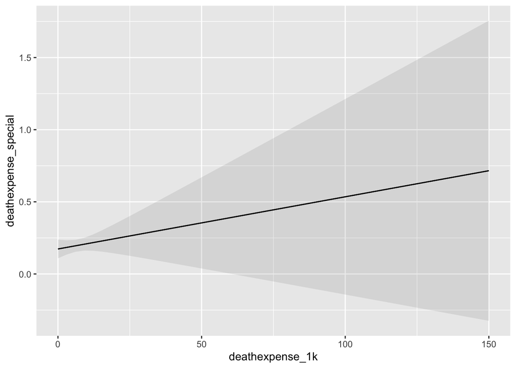

```r
plot_predictions(model, condition = "deathexpense_1k")
```

### C.

```r
point_estimate <- -0.22
se <- 0.06
p <- 1.96  # For a 95% confidence interval

lower_bound <- point_estimate - (p * se)
upper_bound <- point_estimate + (p * se)

# Print results
cat("Approximate 95% Confidence Interval for the Slope:\n")
```

```
Approximate 95% Confidence Interval for the Slope:
```

```r
cat("Lower Bound:", lower_bound, "\n")
```

```
Lower Bound: -0.3376
```

```r
cat("Upper Bound:", upper_bound, "\n")
```

```
Upper Bound: -0.1024
```

### D.

Basic linear probability:

1. Can create predicted probability estimates above 1 and below 0, which does not make mathematical sense.
2. Doesn’t reflect how most independent variables in the world have non-linear relationships with binomial outcome variables
3. Errors are necessarily heteroskedastic, which violates linear regression modeling assumptions.

## 2A.

```r
# set probabilities from prompt
probs <- c(0.5, 0.2, 0.9, 0.997)

# get odds
odds <- probs / (1 - probs)

# get logit
logit <- log(odds)

# show results
result <- data.frame(Probabilities = probs, Odds = odds, Logit = logit)
print(result)
```

```
  Probabilities     Odds     Logit
1         0.500   1.0000  0.000000
2         0.200   0.2500 -1.386294
3         0.900   9.0000  2.197225
4         0.997 332.3333  5.806138
```

## 2B.

```r
# set logits from prompt
logits <- c(0, 2, -1.2, 4.6)

# get odds
odds <- exp(logits)

# get probabilities
probs <- odds / (1 + odds)

# show results
result <- data.frame(Logit = logit, Odds = odds, Probabilities = probs)
print(result)
```

```
      Logit       Odds Probabilities
1  0.000000  1.0000000     0.5000000
2 -1.386294  7.3890561     0.8807971
3  2.197225  0.3011942     0.2314752
4  5.806138 99.4843156     0.9900482
```

## 3.

### A.

The coefficient for ‘male’ is -0.434212, which means that, compared to that of women, the log odds of men’s weekly attendance at church is approx. 0.4342 units lower, holding other variables constant.

### C.

```r
# Get coefficients from prompt
# Don't have female coef? use male coef.
intercept <- 9.949189
edu_coef <- 0.031123
male_coef <- -0.434212
year_coef <- -0.004779

# Set specific X values
edu <- 12 # 12 years of ed
male <- 0 # because the question is about women, set female = 1, and male = 0
year <- 1990

# Calculate logit
logit <- intercept + edu_coef * edu + male_coef * male + year_coef * year

# calculation via function
inverse_logit <- function(x) { #create an inverse logit function. I did this so you would
  y <- exp(x)/(1+exp(x)) #have the code if you ever need it
  return(y)
}

inverse_logit(logit) #voila, a probability!
```

```
[1] 0.6926324
```

### D.

```r
baseline_prob <- 0.3
baseline_logit <- log(baseline_prob / (1 - baseline_prob))

# Get the effect of one additional year of education on weekly church attendance,
# using the partial derivative method, and year_coef from 3C.
effect_of_year <- baseline_prob * (1 - baseline_prob) * year_coef ; effect_of_year
```

```
[1] -0.00100359
```

### E.

Education coefficient: statistically significant at p < 0.05.

Male coefficient: statistically significant at p < 0.001.